# Práctica : Análisis de Dinámica Comunitaria en Ecosistemas Fragmentados

Estructura y Dinámica de Comunidades

Última actualización: 2025-11-08

> ANTES DE CONTINUAR: comienza por aquí, cargando estos paquetes. Si la sesión de R se cierra, deberás comenzar por aquí nuevamente.

```r
# Cargar librerías necesarias
library(tidyverse)
library(vegan)
library(knitr)
library(kableExtra)
library(scales)
library(RColorBrewer)
```

# 1. Introducción

## 1.1 Contexto de la Práctica

- Diversidad de especies (riqueza y equidad)
- Roles ecológicos de especies
- Efectos de la fragmentación del hábitat
- Redes tróficas y cascadas
- Especies invasoras
- Sucesión ecológica
- Resiliencia y estabilidad comunitaria
- Biogeografía de islas

## 1.2 Objetivos de Aprendizaje

1. Calcular y comparar índices de diversidad
2. Identificar roles ecológicos y su vulnerabilidad
3. Analizar efectos de perturbaciones en comunidades
4. Interpretar redes tróficas y cascadas
5. Aplicar conceptos de biogeografía y sucesión

# 2. Datos del Estudio

## 2.1 Descripción del Escenario

Se estudió un ecosistema de bosque tropical que experimentó fragmentación hace 5 años. Se muestrearon tres sitios:

- **Bosque Continuo (BC)**: Hábitat sin fragmentar (control)
- **Fragmento Grande (FG)**: Fragmento de 1000 ha
- **Fragmento Pequeño (FP)**: Fragmento de 100 ha

## 2.2 Carga de Datos

```r
# Crear data frame con abundancia de especies
especies <- data.frame(
  Especie = c("Jaguar", "Puma", "Pecarí", "Venado", "Tapir",
              "Mono aullador", "Tucán", "Ardilla", "Agutí",
              "Serpiente", "Rapaz", "Coatí", "Zarigüeya",
              "Rata invasora", "Insectos defoliadores"),

  Gremio = c("Carnívoro tope", "Carnívoro tope", "Herbívoro",
             "Herbívoro", "Herbívoro", "Frugívoro", "Frugívoro",
             "Granívoro", "Granívoro", "Carnívoro", "Carnívoro",
             "Omnívoro", "Omnívoro", "Omnívoro", "Herbívoro"),

  Rol = c("Especie clave", "Dominante", "Ingeniero", "Nativo",
          "Dispersor/Fundador", "Dispersor", "Dispersor", "Nativo",
          "Dispersor", "Nativo", "Indicador", "Nativo",
          "Generalista", "INVASORA", "Nativo"),

  Bosque_Continuo = c(8, 12, 45, 35, 18, 62, 48, 95, 52,
                      28, 15, 38, 55, 0, 180),

  Fragmento_Grande = c(3, 6, 38, 28, 10, 55, 42, 105, 48,
                       25, 12, 42, 68, 15, 210),

  Fragmento_Pequeno = c(0, 1, 15, 12, 2, 40, 35, 110, 30,
                        22, 8, 45, 85, 45, 260)
)

# Mostrar tabla
kable(especies,
      caption = "Tabla 1: Abundancia de especies en tres sitios de muestreo") %>%
  kable_styling(bootstrap_options = c("striped", "hover", "condensed"),
                full_width = FALSE) %>%
  row_spec(14, bold = TRUE, color = "white", background = "#C00000")
```

Tabla 1: Abundancia de especies en tres sitios de muestreo

| Especie | Gremio | Rol | Bosque_Continuo | Fragmento_Grande | Fragmento_Pequeno |
| --- | --- | --- | --- | --- | --- |
| Jaguar | Carnívoro tope | Especie clave | 8 | 3 | 0 |
| Puma | Carnívoro tope | Dominante | 12 | 6 | 1 |
| Pecarí | Herbívoro | Ingeniero | 45 | 38 | 15 |
| Venado | Herbívoro | Nativo | 35 | 28 | 12 |
| Tapir | Herbívoro | Dispersor/Fundador | 18 | 10 | 2 |
| Mono aullador | Frugívoro | Dispersor | 62 | 55 | 40 |
| Tucán | Frugívoro | Dispersor | 48 | 42 | 35 |
| Ardilla | Granívoro | Nativo | 95 | 105 | 110 |
| Agutí | Granívoro | Dispersor | 52 | 48 | 30 |
| Serpiente | Carnívoro | Nativo | 28 | 25 | 22 |
| Rapaz | Carnívoro | Indicador | 15 | 12 | 8 |
| Coatí | Omnívoro | Nativo | 38 | 42 | 45 |
| Zarigüeya | Omnívoro | Generalista | 55 | 68 | 85 |
| Rata invasora | Omnívoro | INVASORA | 0 | 15 | 45 |
| Insectos defoliadores | Herbívoro | Nativo | 180 | 210 | 260 |

```r
# Datos de cobertura vegetal
vegetacion <- data.frame(
  Estrato = c("Árboles emergentes", "Dosel cerrado", "Sotobosque",
              "Plantas pioneras", "Especies de borde"),
  Bosque_Continuo = c(85, 95, 75, 10, 5),
  Fragmento_Grande = c(70, 80, 70, 25, 35),
  Fragmento_Pequeno = c(45, 55, 60, 50, 65)
)

kable(vegetacion,
      caption = "Tabla 2: Cobertura vegetal (%) en los tres sitios") %>%
  kable_styling(bootstrap_options = c("striped", "hover", "condensed"),
                full_width = FALSE)
```

Tabla 2: Cobertura vegetal (%) en los tres sitios

| Estrato | Bosque_Continuo | Fragmento_Grande | Fragmento_Pequeno |
| --- | --- | --- | --- |
| Árboles emergentes | 85 | 70 | 45 |
| Dosel cerrado | 95 | 80 | 55 |
| Sotobosque | 75 | 70 | 60 |
| Plantas pioneras | 10 | 25 | 50 |
| Especies de borde | 5 | 35 | 65 |

# 3. Actividad 1: Cálculo de Índices de Diversidad

## 3.1 Riqueza de Especies (S)

### 3.1.1 Calcula la Riqueza de Especies (S) para cada sitio

**Respuesta:**

```r
# Calcular riqueza (número de especies presentes)
riqueza <- especies %>%
  select(Bosque_Continuo, Fragmento_Grande, Fragmento_Pequeno) %>%
  summarise(across(everything(), ~ sum(. > 0)))

kable(riqueza,
      caption = "Riqueza de especies (S) por sitio",
      col.names = c("Bosque Continuo", "Fragmento Grande", "Fragmento Pequeño")) %>%
  kable_styling(bootstrap_options = c("striped", "hover"),
                full_width = FALSE)
```

Riqueza de especies (S) por sitio

| Bosque Continuo | Fragmento Grande | Fragmento Pequeño |
| --- | --- | --- |
| 14 | 15 | 14 |

## 3.2 Índice de Shannon-Wiener (H’)

### Calcula el Índice de Shannon-Wiener (H’) para cada sitio

El índice de Shannon mide la diversidad considerando tanto la riqueza como la equitabilidad:

$$H' = -\sum_{i=1}^{S} p_i
\ln(p_i)$$

donde $p_i$ es la proporción de la especie $i$.

Es decir, donde pi = abundancia de la especie i / abundancia total

**Respuesta:**

```r
# Función para calcular Shannon
calcular_shannon <- function(abundancias) {
  total <- sum(abundancias)
  proporciones <- abundancias / total
  proporciones <- proporciones[proporciones > 0]  # Eliminar ceros
  shannon <- -sum(proporciones * log(proporciones))
  return(shannon)
}

# Calcular para cada sitio
shannon_bc <- calcular_shannon(especies$Bosque_Continuo)
shannon_fg <- calcular_shannon(especies$Fragmento_Grande)
shannon_fp <- calcular_shannon(especies$Fragmento_Pequeno)

shannon_df <- data.frame(
  Sitio = c("Bosque Continuo", "Fragmento Grande", "Fragmento Pequeño"),
  Shannon = round(c(shannon_bc, shannon_fg, shannon_fp), 3)
)

kable(shannon_df,
      caption = "Índice de Shannon (H') por sitio") %>%
  kable_styling(bootstrap_options = c("striped", "hover"),
                full_width = FALSE)
```

Índice de Shannon (H’) por sitio

| Sitio | Shannon |
| --- | --- |
| Bosque Continuo | 2.339 |
| Fragmento Grande | 2.264 |
| Fragmento Pequeño | 2.039 |

## 3.3 Índice de Simpson (D’)

### Calcula el Índice Simpson (D’) para cada sitio

El índice de Simpson da más peso a las especies dominantes:

$$D = 1 - \sum_{i=1}^{S}
p_i^2$$

**Respuesta:**

Índice de Simpson (D) por sitio

| Sitio | Simpson |
| --- | --- |
| Bosque Continuo | 0.875 |
| Fragmento Grande | 0.856 |
| Fragmento Pequeño | 0.810 |

## 3.4 Equitabilidad de Pielou

### Calcula la Equidad de Pielou para cada sitio

Mide qué tan equitativa es la distribución de abundancias:

$$J' = \frac{H'}{\ln(S)}$$
**Respuesta:**

Equitabilidad de Pielou (J’) por sitio

| Sitio | Equitabilidad |
| --- | --- |
| Bosque Continuo | 0.886 |
| Fragmento Grande | 0.836 |
| Fragmento Pequeño | 0.773 |

## 3.5 Resumen de Índices de Diversidad

### Completa la tabla con tus datos:

**Respuesta:**

Resumen de índices de diversidad

| Índice | Bosque Continuo | Fragmento Grande | Fragmento Pequeño |
| --- | --- | --- | --- |
| Riqueza (S) | 14.000 | 15.000 | 14.000 |
| Shannon (H’) | 2.339 | 2.264 | 2.039 |
| Simpson (D) | 0.875 | 0.856 | 0.810 |
| Equitabilidad (J’) | 0.886 | 0.836 | 0.773 |

### Interpretación. Responde en base a tus datos:

#### ¿Qué sitio presenta mayor diversidad?

#### ¿Qué componente se afecta más: riqueza o equidad?

# 4. Actividad 2: Análisis de Roles Ecológicos

## 4.1 Cambio en Abundancias

### Identifica qué especies desaparecen o disminuyen drásticamente con la fragmentación

### Clasifica las especies según tu respuesta:

- Especies sensibles (disminuyen >50%)
- Especies tolerantes (cambio <20%)
- Especies beneficiadas (aumentan >20%)

**Respuesta:**

Cambio en abundancias: Bosque Continuo → Fragmento Pequeño

[output not shown]

## 4.2 Visualización de Especies Más Afectadas

### Elabora una gráfica las espcies más afectadas por la fragmentación en función de cambio en la abundancia.

**Respuesta:**

[figure not shown]

Especies más afectadas por la fragmentación

### Resalta los hallazgos clave:

## Interpretación. Responde en base a tus datos:

### ¿Qué rol ecológico es más vulnerable a la fragmentación?

### ¿Qué consecuencias tiene la pérdida de la especie clave?

### ¿Cómo afecta la desaparición del dispersor de semillas, polinizadores…?

# 5. Actividad 3: Red Trófica y Cascadas

## 5.1 Estructura Trófica

### Elabora una tabla de las abundancia de los distintos grupos tróficos por comunidad.

**Respuesta:**

Abundancia total por nivel trófico y sitio

| Nivel_nombre | Bosque Continuo | Fragmento Grande | Fragmento Pequeño |
| --- | --- | --- | --- |
| Carnívoros medianos | 43 | 37 | 30 |
| Carnívoros tope | 20 | 9 | 1 |
| Herbívoros/Frugívoros | 535 | 536 | 504 |
| Omnívoros | 93 | 125 | 175 |

## 5.2 Visualización de la Estructura Trófica

### Construye una gráfica que visaulice las proporciones de abuncancia y distintos niveles de la red trófica entre las comunidades

**Respuesta:**

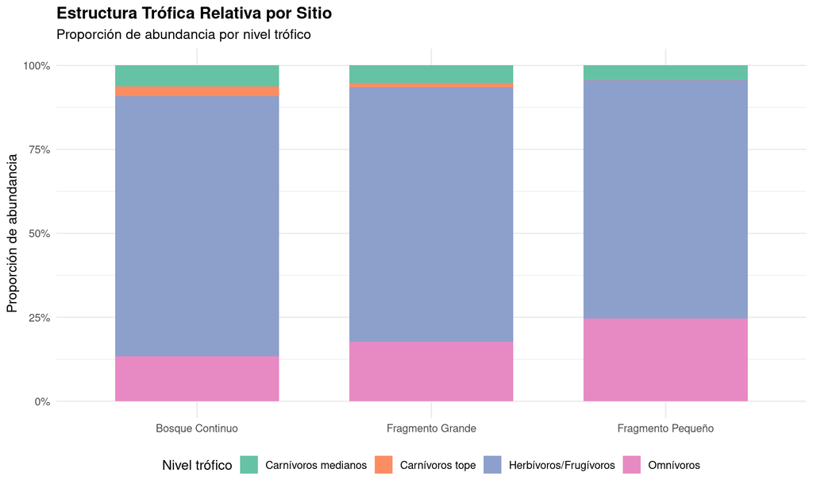

Cambios en la estructura trófica por fragmentación

### ¿Qué niveles tróficos se ven más afectados?

## 5.3 Evidencia de Cascada Trófica

### ¿Hay evidencia de cascada trófica?

# 6. Actividad 4: Especies Invasoras y Efecto de Borde

## 6.1 Análisis de la especie invasora

### Elabora una tabla comparativa de la abundancia de las especies invasora entre las comunidades, señalando las especies de los bordes y las plantas pioneras

**Respuesta:**

Relación entre fragmentación, especies invasoras y efecto de borde

| Sitio | Rata invasora | Especies borde (%) | Plantas pioneras (%) |
| --- | --- | --- | --- |
| Bosque Continuo | 0 | 5 | 10 |
| Fragmento Grande | 15 | 35 | 25 |
| Fragmento Pequeño | 45 | 65 | 50 |

## 6.2 Visualización del Efecto de Borde

### Analiza la relacion entre el tamaño del fragmento, proporcion de especies de borde, y abundncia de especies invasora. Elabora una gráfica que permita visualidad el el tamaño del Efecto de Borde, las Especies Invasoras y las Plantas pioneras.

**Respuesta:**

[figure not shown]

Efecto de borde y especies invasoras

## 6.3 Impacto de la Invasión

### Elabora una tabla comparativa con las especies que podría potencialmente competir con las especies invasoras.

**Respuesta:**

Especies que potencialmente compiten con la rata invasora

| Especie | Gremio | Bosque Contínuo | Fragmento Pequeño | Cambio |
| --- | --- | --- | --- | --- |
| Ardilla | Granívoro | 95 | 110 | 15 |
| Agutí | Granívoro | 52 | 30 | -22 |
| Coatí | Omnívoro | 38 | 45 | 7 |
| Zarigüeya | Omnívoro | 55 | 85 | 30 |
| Rata invasora | Omnívoro | 0 | 45 | 45 |

### Responde las siguientes preguntas

#### ¿Qué evidencia hay de “Efecto de Borde”?

#### ¿Cómo puede la especie invasora alterar la comunidad?

#### ¿Qué especies nativas compiten con la invasora?

# 7. Discusión y Síntesis

## Reflexiona sobre la práctica y resume tus observaciones.

## 7.2 Preguntas para Discusión

### ¿La fragmentación afecta más la riqueza o la equitabilidad?**

**Respuesta:**

La **equitabilidad** se afecta más, indicando que algunas especies se vuelven dominantes mientras otras desaparecen.

Cambio porcentual en índices de diversidad (BC → FP)

| Índice | % Cambio |
| --- | --- |
| Riqueza | 0.0 |
| Shannon | -12.8 |
| Simpson | -7.4 |
| Equitabilidad | -12.8 |

### ¿Qué fragmento muestra menor resiliencia?**

### ¿Se aplica la teoría de biogeografía de islas?**

# 8. Estrategias de Conservación

## En base a tus resultados, Elabora una lsita de recomendaciones estratégicas.

# 9. Conclusiones

## Elabora una lista resumiendo tus conclusiones.

# 10. Referencias y Recursos

## 10.1 Referencias Clave

- MacArthur, R.H. & Wilson, E.O. (1967). *The Theory of Island Biogeography*
- Fahrig, L. (2003). Effects of habitat fragmentation on biodiversity. *Annual Review of Ecology, Evolution, and Systematics*
- Odum, E. P., & Barrett, G. W. (2005). *Fundamentals of Ecology* (5ª ed.). Thomson Brooks/Cole.
- Smith, T. M., & Smith, R. L. (2007). *Ecología* (6ª ed.). Pearson/Addison Wesley.
- Haddad et al. (2015). Habitat fragmentation and its lasting impact on Earth’s ecosystems. *Science Advances*

## 10.2 Paquetes de R Utilizados

**FIN DE LA PRÁCTICA**

*Fecha: 2025-11-08*